# Revisión crítica de studysim (v0.4.0)

Módulo jamovi de estudios médicos simulados para docencia · revisión del 11-10-2026 · basada solo en el código, el tutorial y pruebas propias (no se han leído planes ni notas)

## 1. Resumen

studysim tiene un **valor docente alto** y es poco común: une una biblioteca de 61 escenarios clínicos realistas, 16 diseños que se muestrean de una misma superpoblación y una clave de respuestas que compara la verdad con lo que cada diseño debería estimar. El motor es sólido: está separado de jamovi, es reproducible y su batería de tests pasa entera. Funcionó bien en jamovi 28.4 (Docker).

Aun así, hay **tres problemas de fondo** que afectan justo a lo que el módulo quiere enseñar, y conviene resolverlos antes de usarlo en evaluación:

1. **La clave define la «verdad» como el efecto directo condicional** y ajusta «por todo lo medido». Las variables que actúan solo a través de mediadores salen como «sin efecto». Un alumno que estima bien un efecto total queda como si se hubiera equivocado.
2. **La modificación de efecto (`by:`) no está centrada.** El modificador recibe un efecto principal implícito grande. En *breast_cancer_risk* la OR ajustada de menopausia es 3,0 cuando la clave y el tutorial dicen que no tiene efecto propio (el tutorial publicado muestra 3,06 al lado de ese texto).
3. **La clave no está protegida del alumno.** El diagrama causal con los tamaños de efecto sale por defecto, y la clave completa está a un clic, en el mismo panel que genera los datos.

Además hay 2 errores que bloquean (un escenario cuya clave falla y una combinación de opciones que rompe la simulación), varios fallos menores y bastante margen para mejorar el uso en clase.

**61 / 16**escenarios / diseños

**0 fallos**suite testthat (≈30 s)

**354**simulaciones en el barrido (todos los escenarios × diseños, n = 20 y 300)

**94,5 %**cobertura del IC 95 % en 200 ensayos (indometacina)

## 2. Qué se ha revisado y cómo

- **Código**: todo el motor (`R/engine_*.R`, `derive*.R`, `library_io.R`), las clases jamovi (`*.b.R`), las definiciones `.a/.u/.r.yaml` y el JavaScript del panel.
- **Tutorial**: las 7 páginas de Quarto y el sitio publicado en `docs/`.
- **Tests**: `testthat` completo (todo pasa; solo hay avisos inofensivos de `data.frame` en derive).
- **Barrido**: cada escenario × resultado × diseño compatible, con n = 20 y n = 300, 10 % de datos faltantes MAR, otros resultados activados y la clave calculada en n = 300.
- **Experimentos estadísticos**: calibración, reproducibilidad de la clave de alumno, cobertura del IC sobre 200 réplicas, efectos totales frente a directos, el origen del sesgo de menopausia (escenario modificado sin `by:`) y la no colapsabilidad en ensayos.
- **Interfaz en Docker** (jamovi 28.4 con studysim 0.4.0, manejado con Playwright): análisis por defecto, clave, *Open dataset*, *Compare designs* y escenario EARLY-AF.

## 3. Fortalezas

- **Una superpoblación común a todos los diseños**, generada por bloques con semillas derivadas. La misma persona aparece en cualquier diseño, y comparar diseños tiene sentido real. Los resultados potenciales (el ruido es de la persona) hacen que los ensayos sean contrafactuales de verdad.
- **La clave de «lo que el diseño debería estimar»** sale de un estudio grande del mismo diseño, con el mismo error de medida y la misma categorización. Es la idea más valiosa del módulo: separa sesgo de azar y deja ver que el OR de un caso-control no es el HR que generó los datos.
- **Amplitud de diseños**: casos y controles anidado (con conjuntos de riesgo), caso-cohorte (Prentice con varianza robusta), cluster con CCI, factorial con interacción, crossover con periodo y arrastre, longitudinal con abandono MAR, antes-después con regresión a la media, Bland-Altman, riesgos competitivos y enfermedad-muerte.
- **Capa de realismo bien pensada**: faltantes MCAR/MAR/MNAR, fiabilidad, clasificación errónea, límites de detección, lotes de laboratorio (que pueden confundirse con el estado de enfermedad), errores de transcripción y variables ruido.
- **Escenarios con procedencia**: muchos se han derivado de datos abiertos con el propio motor *Derive*, y llevan referencias y nota docente en tres idiomas.
- **Ingeniería cuidada**: el motor es R puro y testeable; las expresiones de la biblioteca se evalúan en un entorno cerrado (no ejecutan código arbitrario); el YAML se lee con `eval.expr = FALSE`; los problemas de la biblioteca se recogen en lenguaje llano; y la interfaz está traducida (es/ca) casi por completo.

## 4. Errores y problemas, por prioridad

### AltaE1. «Verdad» = efecto directo; variables mediadas marcadas como nulas

La tabla *true model* da el coeficiente condicional del modelo generador. Las `null_variables` salen como «no effect (null variable)» aunque tengan efecto causal a través de la estructura. Además, el «Adjusted» esperado ajusta siempre por **todas** las variables medidas, también por los mediadores (la «falacia de la Tabla 2»).

| Escenario chd_incidence (cohorte) | Clave: verdad | Estimación sin ajustar por mediadores | Ajustado por todo |
| --- | --- | --- | --- |
| education, secundaria vs primaria | 1,00 «nula» | 0,87 | 0,91 |
| sexo, hombre vs mujer (tabla del tutorial) | 1,60 | 1,76 (HDL no medido, mediador) | 1,61 |
| edad, por año (tabla del tutorial) | 1,05 | 1,07 (PAS, colesterol, diabetes, mediadores) | 1,05 |

La nota docente del escenario explica la mediación, pero las tablas la contradicen: lo correcto según el DAG aparece como sesgado, y la clave premia «ajustar por todo».

**Propuesta**: (a) añadir una columna de **efecto total**, calculado por intervención en el modelo latente (desplazar Z<sub>x</sub> y regenerar sus descendientes); el motor ya tiene todo lo necesario para hacerlo; (b) calcular el «esperado» con el **conjunto de ajuste mínimo** del DAG para cada exposición, además del modelo mutuamente ajustado; (c) renombrar «null variable» a «sin efecto directo» cuando tenga descendientes en la estructura.

### AltaE2. Modificación de efecto sin centrar: efecto fantasma del modificador

`effect_contrib()` calcula `coef[nivel] × x/per`. Con `bmi: {HR 1.12 per 5, by: {menopause: {pre: 0.93, post: 1.12}}}`, el contraste post vs pre vale 1 solo cuando IMC = 0. Con el IMC medio (26,5), el HR implícito post vs pre es **2,68**.

| breast_cancer_risk, caso-control (edad, menopausia, paridad, antecedentes, alcohol) | OR cruda menopausia | OR ajustada |
| --- | --- | --- |
| Escenario original (clave: verdad = 1,00, «confusión pura») | 6,55 | 3,00 |
| Mismo escenario sin `by:` en IMC | 2,34 | 0,98 |

El tutorial publicado (*Teaching ▸ Odds ratios from a case-control study*) muestra la OR ajustada de 3,06 justo debajo de «Menopause has no effect of its own… pure confounding». En la misma clave, TRH (verdad 1,5) sale con 1,72. Se aplica igual a *cervical_cancer_hpv* (oc_years, parity por HPV), pero ahí 0 es un valor con sentido (nunca usuaria, nulípara), así que no hay problema.

**Propuesta**: un campo `center:` (por defecto, la media o la mediana poblacional de x) en los efectos con `by:`; un aviso en `check_library` cuando 0 queda fuera del rango de x; la clave debe dar el efecto del modificador en el valor de referencia; y revisar el texto del escenario y del tutorial.

### AltaE3. La clave está al alcance del alumno

- `showDag = true` y `dagValues = true` por defecto: cada estudio muestra, sin tocar nada, qué variables son confusoras o nulas y los HR/OR verdaderos en las flechas.
- *Answer key* y *Answer key report* están en el mismo panel que *Open dataset*. Con el flujo de «clave de alumno», cada estudiante genera sus datos en su jamovi y, por tanto, tiene la solución a un clic. El tutorial llama a la clave «hidden», pero no lo está.

**Propuesta**: valores del DAG desactivados por defecto (o el DAG entero); un **modo profesor**: generación por lotes a partir de una lista de identificadores, con un zip de CSV por alumno más una sola clave HTML. Así el alumno recibe solo el CSV. De forma opcional, un código de profesor (hash) que habilite la clave.

### MediaE4. EARLY-AF «af_burden»: la clave falla con un error crudo de R

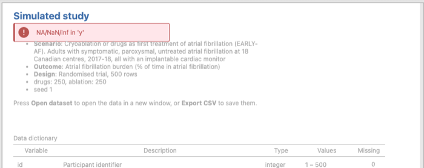

jamovi 28.4: al activar *Answer key* en EARLY-AF › AF burden › ensayo aleatorizado.

El resultado está en escala logarítmica (media geométrica 0,13, **DE del log 3,7**), con rango [0, 100] y redondeo. Muchos valores quedan en 0 exacto (mediana 0,0 [0,0; 0,4]), y `lm(log(y))` falla en el estudio grande de la clave. El alumno tampoco puede hacer el análisis log que la clave presupone.

**Propuesta**: en `normalize_outcome`, validar que una escala log no admita valores ≤ 0 tras el rango y el redondeo (o modelar la carga de otra manera, p. ej. como binaria «carga > 0» más la carga positiva); envolver la clave en `tryCatch` con un mensaje comprensible.

### MediaE5. Faltantes «dependiendo del resultado» + comparación de métodos: la simulación se rompe

En `simulate_study()`, `driver = oc$id`, pero la comparación de métodos no tiene esa columna (genera `sbp_a`/`sbp_b`). `apply_missing` recibe un vector vacío y `uniroot` falla con «f.lower = f(lower) is NA». Ocurre en los 4 escenarios con comparación de métodos, con cualquier n. MCAR y MNAR funcionan.

**Propuesta**: usar `paste0(oc$id, "_a")` como variable motriz, o desactivar MAR en ese diseño con un aviso.

### MediaE6. Casos y controles ordenados: el `id` revela el estado

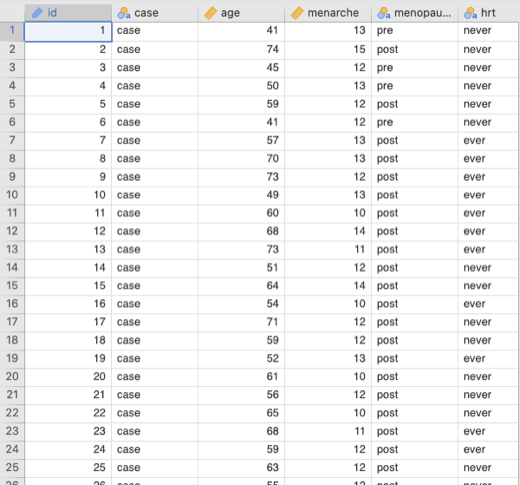

Caso-control por defecto: las filas 1–250 son todas casos.

`sim_case_control` devuelve `pool[c(cases, ctrl)]`, así que `id ≤ n_casos` equivale a ser caso. No es realista y da una pista trivial.

**Propuesta**: barajar las filas con una semilla derivada y renumerar `id` (también en caso-cohorte si se quiere ocultar quién pertenece a la subcohorte).

### MediaE7. El «esperado» tiene un error de Monte Carlo que no se muestra

Sale de un solo estudio grande con semilla fija. En indometacina (ensayo, OR verdadera 0,47), el esperado ajustado es 0,494 (+5 %), mientras que la media de 200 ensayos de n = 600 es 0,475 y la cobertura del IC 95 % es del 94,5 %. El esperado se muestra con 3 decimales, como si fuera exacto, y una diferencia del 5 % se parece mucho a un sesgo de confusión pequeño.

**Propuesta**: mostrar el EE de Monte Carlo (o un intervalo), promediar varias réplicas, o redondear a la precisión real.

### BajaOtros fallos menores

- **Variables derivadas colineales** (*msi_crc_pathology*: til_count, til, til_log2, til_high): «ajustado por todo» las incluye todas, el coeficiente queda aliasado y la celda aparece vacía sin explicación. Conviene excluir las fórmulas de una misma base o añadir una nota.
- **Variables de emparejamiento** (sexo, edad agrupada, paridad en el emparejado): la celda ajustada sale vacía, cuando es justamente un punto docente («no estimable por diseño»). Falta una nota.
- **Catálogo del tutorial**: a `design_names` (`scenarios.qmd`) le faltan `pre_post` y `method_comparison`, así que 7 escenarios muestran `null` en sus diseños y el filtro no los encuentra.
- *How it works* desactualizado: la tabla de diseños tiene 6 de 16, y dice «20 000 filas» cuando el código usa entre 40 000 y 300 000.
- **Lógica duplicada R/JS**: `designsFor()` (JS) replica `compatible_designs()` (R) pero no la rama de enfermedad-muerte (`after:`). Hoy no afecta porque colon_adjuvant declara `designs:`, pero se acabarán separando; mejor generar la lista de diseños compatibles en `build-library-js.R`.
- **«0 = valor del escenario»** (sesgo de método, reclutamiento, periodo, arrastre): no se puede fijar 0 cuando el escenario trae otro valor.
- **Clave de alumno sensible a mayúsculas** («anna» ≠ «Anna»). Conviene normalizarla o avisarlo.
- **Recorte de resultados continuos** a su rango con `pmin/pmax`: acumula valores en los extremos (100 % en carga de FA, 0 en BDI), mientras que las covariables se truncan exactamente.
- **Mensajes de error crudos** de R en la interfaz (E4, E5): conviene un manejador común con mensajes traducidos.
- **Repositorio**: `scenarios/CLX/` (informe Colonomics, YAML derivado, un fichero `gemini-code-*.yaml`) está versionado y hay 50 commits sin publicar. Hay que decidir si debe ir al GitHub público, porque deriva de datos no abiertos.

## 5. Sugerencias para mejorar la docencia

### Uso en clase

- **Guía «cómo analizarlo en jamovi» por diseño.** El tutorial no dice con qué análisis o módulo hacer cada cosa: Cox y Kaplan-Meier, regresión logística condicional, modelos mixtos, Bland-Altman y ROC no están en jamovi base. Haría falta una tabla diseño → análisis → módulo recomendado (p. ej. jsurvival, GAMLj, blandr; verificar disponibilidad), con un ejercicio resuelto para cada uno.
- **Formato ancho opcional** para crossover y longitudinal: la ANOVA de medidas repetidas y la t pareada de jamovi necesitan una fila por persona, y ahora mismo esos datos solo salen en formato largo.
- **Exportar el diccionario** junto al CSV (codebook), porque la descripción de las columnas se pierde al exportar.
- **Generación por lotes para el profesor** (ver E3), con un registro de semilla y clave por alumno.

### Contenido estadístico

- **Réplicas**: «simular 200 estudios» en *Compare designs*, con la distribución de las estimaciones, la potencia (% significativo), la cobertura del IC y el sesgo. Es la forma más directa de enseñar azar frente a sesgo, y el motor es lo bastante rápido (≈0,1–0,3 s por estudio pequeño).
- **Medidas absolutas en ensayos**: riesgo por brazo, DR, NNT, y OR/HR marginal frente a condicional (no colapsabilidad). Los resultados potenciales ya están, así que es barato añadirlo.
- **Aviso de EPV**: *Compare designs* por defecto ajusta una cohorte con 10 eventos y unos 14 parámetros (HR de TRH 6,6, IC 1,1–39). Faltan un aviso de «menos de 10 eventos por parámetro» y la opción de ajustar solo por la exposición y los confusores.
- **Sesgos que hoy no se pueden generar** y son centrales en epidemiología: selección de controles relacionada con la exposición (controles hospitalarios, Berkson), **clasificación errónea diferencial** (sesgo de recuerdo; ahora solo es no diferencial), no adherencia o cruce en ensayos (ITT frente a por protocolo), censura informativa, tiempo inmortal, sesgo de verificación y de espectro en estudios diagnósticos, y variables posteriores al resultado (colisionadores).
- **Estudios diagnósticos**: los marcadores son independientes de las covariables y la clave da solo el AUC. Se podrían añadir sensibilidad, especificidad, VPP y VPN en un punto de corte, y marcadores que dependan de la edad o la gravedad.
- **Estimandos explícitos** en la clave: «efecto condicional en el modelo generador», «efecto total», «poblacional», «por protocolo»… Cada columna debería decir qué estima.

## 6. Prioridades recomendadas

| # | Acción | Esfuerzo |
| --- | --- | --- |
| 1 | E2: centrar `by:`, revisar breast_cancer_risk y el tutorial | bajo |
| 2 | E4/E5/E6: los dos errores bloqueantes y el orden de filas | bajo |
| 3 | E3: valores del DAG desactivados por defecto; generación por lotes para el profesor | medio |
| 4 | E1: efecto total y conjunto de ajuste mínimo en la clave | medio-alto |
| 5 | Guía de análisis en jamovi, formato ancho, codebook | medio |
| 6 | Réplicas, medidas absolutas, nuevos sesgos | alto |

## Anexo: problemas del barrido (354 ejecuciones)

| Escenario | Diseño | Resultado | Valoración |
| --- | --- | --- | --- |
| antihypertensive, lead_succimer, metformin, nhanes | method_comparison | ERROR f.lower… (n = 20 y 300) | Fallo E5 |
| early_af_cryoablation (af_burden) | rct | ERROR NA/NaN/Inf in 'y' (clave) | Fallo E4 |
| msi_crc_pathology (til) | cross_sectional, case_control | ajustado vacío | Aliasado (menor) |
| chd, colorectal, esoph, infertility, lung | matched_cc | ajustado vacío en variables emparejadas | Esperado; falta nota |
| 4 escenarios | pre_post | ajustado = NA | Por diseño (correcto) |

Más lento con clave: cervical_cancer_hpv emparejado, 43 s; colorectal_diet emparejado, 18 s; el resto, menos de 8 s. Scripts y salidas en `.tmp/review/`.